# Epilepsy GLMM example

Adam Howes

Abstract

**Background** Rue, Martino, and Chopin (2009) use the epilespy example from the OpenBUGs manual as demonstration of the integrated nested Laplace approximation method. The model is a Poisson GLMM including both fixed and random effects.

**Task** We implement the epilepsy example in Stan, `R-INLA`, `TMB`, `glmmTMB`, `tmbstan`, `aghq`, and a custom Laplace marginal version of `aghq`. We then compare the results of the inference methods. This serves to compare inference methods, and check new methods are behaving as expected.

```r
knitr::opts_chunk$set(
  cache = TRUE,
  autodep = TRUE,
  cache.lazy = FALSE,
  cache.comments = FALSE
)
options(scipen = 999)
cbpalette <- multi.utils::cbpalette()
library(tidyverse)

rstan::rstan_options(auto_write = TRUE)
options(mc.cores = parallel::detectCores())
```

# 1 Background

## 1.1 Model description

Section 5.2. of Rue, Martino, and Chopin (2009) demonstrates the application of `R-INLA` to a generalised linear mixed model. The data, previously included as an example in the OpenBUGs manual, concern the results of a clinical trial for a new epilepsy drug. Patients $i = 1, \ldots, 59$ are each either assigned the new drug $\texttt{Trt}_i = 1$ or placebo $\texttt{Trt}_i = 0$. Each patient makes four visits the clinic $j = 1, \ldots, 4$. The observations $y_{ij}$ give the number of seizures of the $i$th person in the two weeks preceeding their $j$th visit to the clinic. The covariates are age $\texttt{Age}_i$, baseline seizure counts $\texttt{Base}_i$ and an indicator for the final clinic visit $\texttt{V}_4$, which are all centered.

The observations are modeleed using a Poisson distribution $y_{ij} \sim \text{Poisson}(e^{\eta_{ij}})$ with linear predictor
$$\begin{align*}
\eta_{ij}
&= \beta_0 + \beta_\texttt{Base} \log(\texttt{Baseline}_j / 4) + \beta_\texttt{Trt} \texttt{Trt}_i +
\beta_{\texttt{Trt} \times \texttt{Base}} \texttt{Trt}_i \times \log(\texttt{Baseline}_j / 4) \\
&+ \beta_\texttt{Age} \log(\texttt{Age}_i) + \beta_{\texttt{V}_4} {\texttt{V}_4}_j +
\epsilon_i + \nu_{ij}, \quad i=1:59, \quad j=1:4,
\end{align*}$$
where the prior on each of the regression parameters, including the intercept, is $\mathcal{N}(0, 100^2)$. The random effects are IID $\epsilon_i \sim \mathcal{N}(0, 1/\tau_\epsilon)$ and $\nu_{ij} \sim \mathcal{N}(0, 1/\tau_\nu)$ with precision priors $\tau_\epsilon, \tau_\nu \sim \Gamma(0.001, 0.001)$.

## 1.2 Data preparation

The data is available within `R-INLA` as follows:

```r
data(Epil, package = "INLA")
head(Epil)
```

|  | y | Trt | Base | Age | V4 | rand | Ind |
| --- | --- | --- | --- | --- | --- | --- | --- |
| 1 | 5 | 0 | 11 | 31 | 0 | 1 | 1 |
| 2 | 3 | 0 | 11 | 31 | 0 | 2 | 1 |
| 3 | 3 | 0 | 11 | 31 | 0 | 3 | 1 |
| 4 | 3 | 0 | 11 | 31 | 1 | 4 | 1 |
| 5 | 3 | 0 | 11 | 30 | 0 | 5 | 2 |
| 6 | 5 | 0 | 11 | 30 | 0 | 6 | 2 |

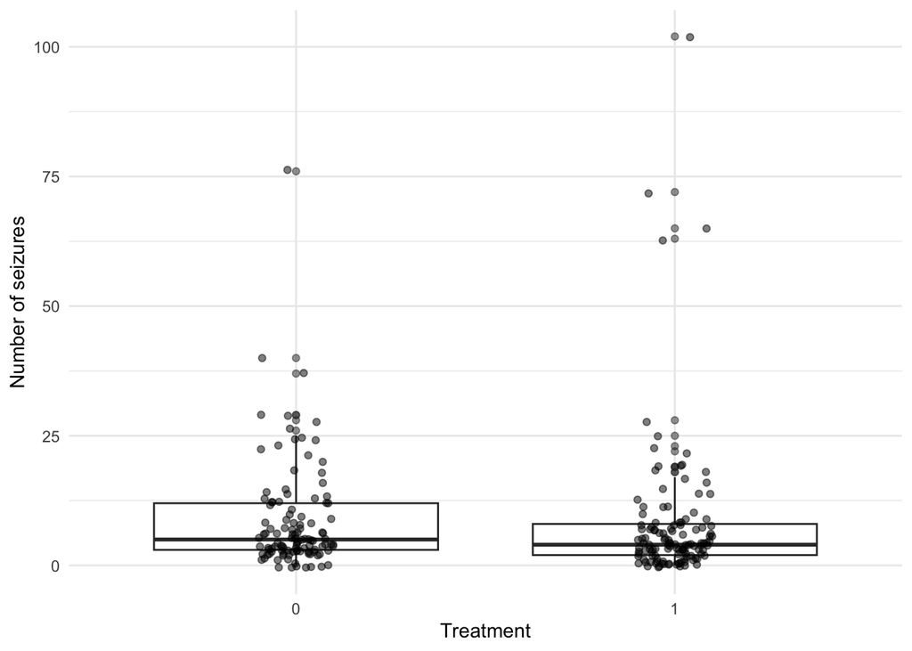

Figure 1.1: It looks like treatment is associated to fewer seizures on average, but of course we haven’t accounted for the different covariates, hence the use of a statistical model!

```r
Epil %>% ggplot(aes(x =  as.factor(Trt), y = y)) +
  geom_boxplot(alpha = 0.5) +
  geom_jitter(width = 0.1, alpha = 0.5) +
  theme_minimal() +
  labs(x = "Treatment", y = "Number of seizures")
```

We modify the `Epil` dataframe by centering all of the covariates:

```r
center <- function(x) (x - mean(x))

Epil <- Epil %>%
  mutate(CTrt    = center(Trt),
         ClBase4 = center(log(Base/4)),
         CV4     = center(V4),
         ClAge   = center(log(Age)),
         CBT     = center(Trt * log(Base/4)))
```

We will implement the model based upon a response variable of length $N \times J$, where $N$ is the number of patients and $J$ is the number of visits to the clinic, and a model matrix with $K$ predictors (including the intercept term):

```r
N <- 59
J <- 4
K <- 6
X <- model.matrix(formula(~ 1 + CTrt + ClBase4 + CV4 + ClAge + CBT), data = Epil)
y <- Epil$y
```

For the individual specific random effect $\epsilon_i$ we use a transformation matrix `E` which repeats elements of vector of length `N` each `J` times.

```r
make_epsilon_matrix <- function(N, J) {
  t(outer(1:N, 1:(N * J), function(r, c) as.numeric((J*(r - 1) < c) & (c <= J*r))))
}
```

For example, with $N = 3$ and $J = 2$:

```r
E <- make_epsilon_matrix(N = 3, J = 2)
E
```

```
##      [,1] [,2] [,3]
## [1,]    1    0    0
## [2,]    1    0    0
## [3,]    0    1    0
## [4,]    0    1    0
## [5,]    0    0    1
## [6,]    0    0    1
```

```r
t(E %*% c(1, 2, 3)) # Same as rep(1:3, 2)
```

```
##      [,1] [,2] [,3] [,4] [,5] [,6]
## [1,]    1    1    2    2    3    3
```

Multiplying this matrix $E$ by the vector $\epsilon$ allows it to be directly added to the linear predictor $\eta = \beta X + \nu + E \epsilon$, where $\beta$ is the vector of coefficients and $X$ is the model matrix.

```r
dat <- list(N = N, J = J, K = K, X = X, y = y, E = make_epsilon_matrix(N, J))
```

# 2 Inference methods

We consider a range of inference methods, described below.

## 2.1 Stan

First, Hamiltonian Monte Carlo (HMC) via the No-U-Turn Sampler (NUTS) algorithm, with four Markov chains of `iter = 1000` samples, and `warmup = 100` burn-in. Markov chain Monte Carlo (MCMC) like NUTS are exact as the number of samples tends to infinity. We provide the `stan` function with `file = "epil.stan"` which refers to a C++ file implementing the log-posterior in the Stan probabilistic programming language:

```r
start_fit1 <- Sys.time()

fit1 <- stan(
  file = "epil.stan",
  data = dat,
  chains = 4,
  warmup = 100,
  iter = 1000,
  control = list(adapt_delta = 0.95),
  refresh = 0
)

end_fit1 <- Sys.time()
time_fit1 <- end_fit1 - start_fit1
time_fit1
```

```
## Time difference of 19.43963 secs
```

It took 19.44 seconds to fit this model. All of the $\hat R$ values are below 1.05, so it looks like the MCMC has reached convergence:

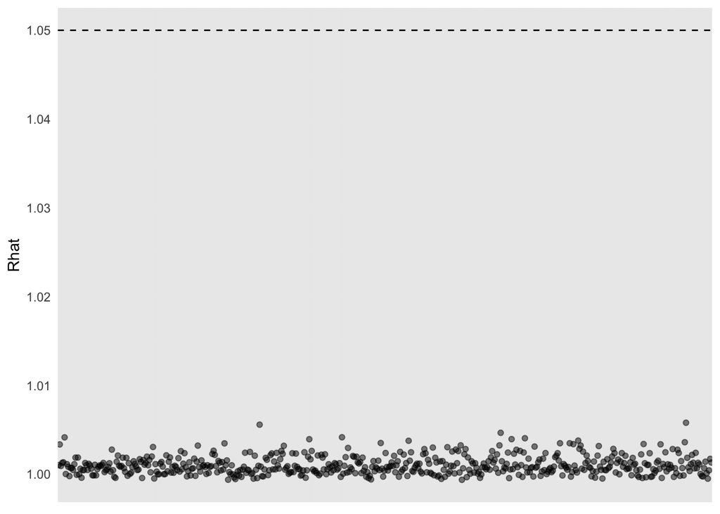

```r
monitor1 <- rstan::monitor(fit1, print = FALSE)

monitor1 %>%
  as.data.frame() %>%
  tibble::rownames_to_column(var = "parameter") %>%
  ggplot(aes(x = parameter, y = Rhat)) +
  geom_point(alpha = 0.5) +
  geom_hline(yintercept = 1.05, linetype = "dashed") +
  labs(x = "Parameter")  +
  theme_minimal() +
  theme(
    axis.title.x = element_blank(),
    axis.text.x = element_blank(),
    legend.position = "bottom"
  )
```

## 2.2 `R-INLA`

`R-INLA` is an R package which implements integrated nested Laplace approximations. Rather than specifying the log-posterior via C++, the package uses a formula interface. This makes it easy to specify common models, but does limit the flexibility of the package for more advanced users.

We specify the $\Gamma(0.001, 0.001)$ prior on the random effects $\tau_\epsilon$ and $\tau_\nu$ below. In `R-INLA`, the precision is internally represented as log-precision, therefore we must set a `loggamma` prior.

```r
tau_prior <- list(prec = list(
  prior = "loggamma",
  param = c(0.001, 0.001),
  initial = 1,
  fixed = FALSE)
)
```

The variable `Epil$rand` is gives the row number for each entry and the variable `Epil$Ind` gives the patient number. These variables can be used to define the IID random effects $\nu_{ij}$ and $\epsilon_i$ in `R-INLA` as follows. The usual R formula notation (e.g. `y ~ x1 + x2`) is used for the rest of the linear predictor.

```r
formula <- y ~ 1 + CTrt + ClBase4 + CV4 + ClAge + CBT +
  f(rand, model = "iid", hyper = tau_prior) +  #' Nu random effect
  f(Ind,  model = "iid", hyper = tau_prior)    #' Epsilon random effect
```

We can use various settings (`"gaussian"`, `"simplified.laplace"` and `"laplace"`) for the `strategy` passed to `control.inla`, which controls the approximation used for the latent field posterior marginals. We create a function `epil_inla` which takes as input the latent field approximation strategy, as well as the hyperparameter quadrature approach:

```r
epil_inla <- function(strat, int_strat) {
  inla(
    formula,
    control.fixed = list(mean = 0, prec = 1 / 100^2), #' Beta prior
    family = "poisson",
    data = Epil,
    control.inla = list(strategy = strat, int.strategy = int_strat),
    control.predictor = list(compute = TRUE)
  )
}

start_fit2 <- Sys.time()
fit2 <- epil_inla(strat = "gaussian", int_strat = "eb")
end_fit2 <- Sys.time()
(time_fit2 <- end_fit2 - start_fit2)
```

```
## Time difference of 4.481125 secs
```

```r
start_fit3 <- Sys.time()
fit3 <- epil_inla(strat = "simplified.laplace", int_strat = "eb")
end_fit3 <- Sys.time()
(time_fit3 <- end_fit3 - start_fit3)
```

```
## Time difference of 4.336194 secs
```

```r
start_fit4 <- Sys.time()
fit4 <- epil_inla(strat = "laplace", int_strat = "eb")
end_fit4 <- Sys.time()
(time_fit4 <- end_fit4 - start_fit4)
```

```
## Time difference of 4.49743 secs
```

```r
start_fit5 <- Sys.time()
fit5 <- epil_inla(strat = "gaussian", int_strat = "grid")
end_fit5 <- Sys.time()
(time_fit5 <- end_fit5 - start_fit5)
```

```
## Time difference of 4.40382 secs
```

```r
start_fit6 <- Sys.time()
fit6 <- epil_inla(strat = "simplified.laplace", int_strat = "grid")
end_fit6 <- Sys.time()
(time_fit6 <- end_fit6 - start_fit6)
```

```
## Time difference of 4.440583 secs
```

```r
start_fit7 <- Sys.time()
fit7 <- epil_inla(strat = "laplace", int_strat = "grid")
end_fit7 <- Sys.time()
(time_fit7 <- end_fit7 - start_fit7)
```

```
## Time difference of 6.758156 secs
```

## 2.3 `TMB`

Template Model Builder, or `TMB`, is an R package which implements the Laplace approximation using automatic differentiation. The user writes a C++ file, here `epil.cpp` (see appendix), which contains the negative log-posterior for the model in question:

```r
compile("epil.cpp")
```

```
## [1] 0
```

```r
dyn.load(dynlib("epil"))
```

We need to specify the initialisation parameters:

```r
param <- list(
  beta = rep(0, K),
  epsilon = rep(0, N),
  nu = rep(0, N * J),
  l_tau_epsilon = 0,
  l_tau_nu = 0
)
```

We integrate the random effects, `random`, out with a Laplace approximation. Here these corresponds to `c("beta", "epsilon", "nu")`:

```r
#' Note: Perhaps you could argue about when the "start" and "end" of the model fitting are
#' For example, is compilation of the TMB template part of the model fitting?
start_fit8 <- Sys.time()

obj <- MakeADFun(
  data = dat,
  parameters = param,
  random = c("beta", "epsilon", "nu"),
  DLL = "epil",
  silent = TRUE
)
```

The objective function `obj$fn` and its gradient `obj$gn` are a function of only the parameters, which in this instance are the logarithms of $\tau_\epsilon$ and $\tau_\nu$. This can be checked with `names(obj$par)`. We optimise `obj` using 1000 iterations of the the `nlminb` optimiser, passing in the starting values `start`, objective function `objective` and its derivative `gradient`:

```r
its <- 1000 #' May converge before this

opt <- nlminb(
  start = obj$par,
  objective = obj$fn,
  gradient = obj$gr,
  control = list(iter.max = its, trace = 0)
)

sd_out <- sdreport(
  obj,
  par.fixed = opt$par,
  getJointPrecision = TRUE
)

end_fit8 <- Sys.time()
(time_fit8 <- end_fit8 - start_fit8)
```

```
## Time difference of 0.1567409 secs
```

### 2.3.1 Check `TMB` objective is the same as Stan

For completeness, we verify that the objective functions as implemented in `TMB` and Stan are identical. This is actually quite difficult to do, so pat it’s worth checking, and giving yourself a pat on the back if they are. To obtain the `TMB` negative log-posterior we call `MakeADFun` as before, but now do not specify any parameters to be integrated out. For Stan, we create an empty model, then use `rstan::log_prob`:

```r
tmb_nll <- MakeADFun(data = dat, parameters = param, DLL = "epil")
stan_nll <- stan("epil.stan", data = dat, chains = 0)
```

```
## the number of chains is less than 1; sampling not done
```

We can test the NLL of the initialisation parameters `param`:

```r
c("TMB" = tmb_nll$fn(unlist(param)), "Stan" = -rstan::log_prob(object = stan_nll, unlist(param)))
```

```
##      TMB     Stan
## 4365.854  236.002
```

But these look different! This is just because the two functions are different by a constant, which we can show by evaluating the NLL at some of the other parameters explored during the MCMC:

```r
pars_mat <- as.matrix(fit1)
pars_list <- apply(pars_mat, 1, function(x) relist(flesh = x, skeleton = fit1@inits[[1]]))
#' Note that Stan transformed constrained parameters in the parameters block to unconsrained parameters that can be sampled from
upars_list <- lapply(pars_list, function(x) rstan:::unconstrain_pars(fit1, x))
```

Using just a few of them, we can see that the difference between the `TMB` and Stan objectives is a constant:

```r
test_pars <- upars_list[500:510]
tmb_evals <- sapply(test_pars, tmb_nll$fn)
stan_evals <- -sapply(test_pars, FUN = rstan::log_prob, object = stan_nll)

data.frame(
  "TMB" = tmb_evals,
  "Stan" = stan_evals
) %>%
  mutate(Difference = TMB - Stan) %>%
  pull(Difference)
```

```
##  [1] 4129.852 4129.852 4129.852 4129.852 4129.852 4129.852 4129.852 4129.852 4129.852 4129.852 4129.852
```

Note: When there are errors in the C++ template code, usually to do with indexing (unlike Stan, in `TMB` there is no requirement when defining variables to give them dimensions), calling the `MakeADFun` function tends to crash the R session. A workaround (courtesy of Kinh) for debugging without crashing the working R session is to use the following (which creates new R sessions which crash in preference to the working R session):

```r
library(parallel)

testrun <- mcparallel({MakeADFun(data = dat,
                                 parameters = param,
                                 DLL = "epil")})

obj <- mccollect(testrun, wait = TRUE, timeout = 0, intermediate = FALSE)
```

## 2.4 `glmmTMB`

[`glmmTMB`](https://glmmtmb.github.io/glmmTMB/) is an R package written by Ben Bolker and collaborators which allows fitting generalised linear mixed models in `TMB` without writing the C++ code manually as we have in `epil.cpp`. For example, rather than writing `epil.cpp`, we could have called the following:

```r
start_fit9 <- Sys.time()
formula9 <- y ~ 1 + CTrt + ClBase4 + CV4 + ClAge + CBT + (1 | rand) + (1 | Ind)
fit9 <- glmmTMB(formula9, data = Epil, family = poisson(link = "log"))
end_fit9 <- Sys.time()
(time_fit9 <- end_fit9 - start_fit9)
```

```
## Time difference of 0.8262661 secs
```

This won’t be exactly the same model, in terms of priors and so on, but it may be close. We mention this package here in case it is of interest, but will not focus on it during the remainder of this notebook, as we would like to compare inferential methods on exactly the same model.

## 2.5 `tmbstan`

[`tmbstan`](https://journals.pl,os.org/plosone/article?id=10.1371/journal.pone.0197954) (Cole Monnahan and Kasper Kristensen) is another helpful `TMB` package which allows you to pass the same C++ template you use in `TMB` to Stan in order to perform NUTS (if you have standard C++ code then this can also likely be done using [`stanc`](https://statmodeling.stat.columbia.edu/2017/03/31/running-stan-external-c-code/)).

```r
start_fit10 <- Sys.time()
fit10 <- tmbstan(obj = obj, chains = 4, refresh = 0)
end_fit10 <- Sys.time()
(time_fit10 <- end_fit10 - start_fit10)
```

```
## Time difference of 59.5346 secs
```

The results from `tmbstan`, up to stochasticity of the MCMC sampler, should be exactly the same as those we might generate from Stan – given that we have confirmed the objective functions they are sampling from are identical up to a constant. For this reason, we do not need to focus on these results in the remainder of the notebook, but again highlight this package in case it is of interest.

## 2.6 `aghq`

[`aghq`](https://arxiv.org/pdf/2101.04468.pdf) is an R package written by Alex Stringer which implements adaptive Gauss-Hermite quadrature. It also works smoothly with `TMB` templates. The parameter `k = 3` determines the number of quadrature points per dimension:

```r
start_fit11 <- Sys.time()
fit11 <- aghq::marginal_laplace_tmb(
  obj,
  k = 3,
  startingvalue = c(param$l_tau_epsilon, param$l_tau_nu)
)

fit11_samples <- aghq::sample_marginal(fit11, M = 1000)$samps %>%
  t() %>%
  as.data.frame() %>%
  inf.utils::replace_duplicate_colnames()
end_fit11 <- Sys.time()
(time_fit11 <- end_fit11 - start_fit11)
```

[output not shown]

Another (non-standard) approach that is possible is to use `glmmTMB` to get the `TMB` template which can then be passed to `aghq`.

```r
glmm_model_info <- glmmTMB(formula9, data = Epil, family = poisson(link = "log"), doFit = FALSE)

glmm_ff <- with(glmm_model_info, {
  TMB::MakeADFun(
    data = data.tmb,
    parameters = parameters,
    random = names(parameters)[grep("theta", names(parameters), invert = TRUE)],
    DLL = "glmmTMB",
    silent = TRUE
  )
})
```

```r
glmm_quad <- aghq::marginal_laplace_tmb(glmm_ff, k = 3, startingvalue = glmm_ff$par)
```

This could be useful in situations where you don’t have a `TMB` template written.

## 2.7 Custom Laplace method with `aghq`

Ok, this next section is going to be a bit more involved.

### 2.7.1 Empirical Bayes with multiple C++ template

Let’s just starting by trying to get the Laplace marginals for $\beta$. To do this, we create the `TMB` template `epil_beta_index.cpp` (see appendix) which has the `beta` parameter replaced by `beta_i` and `beta_minus_i`. As well, there is an additional `DATA_INTEGER(i)` allowing us to pass in the index of `i` that we would like to obtain a full Laplace approximation to.

```r
compile("epil_beta_index.cpp")
```

```
## [1] 0
```

```r
dyn.load(dynlib("epil_beta_index"))
```

We have already obtained the MAP estimate $\hat \theta$ in the `TMB` section above that we can use in our empirical Bayes procedure.

```r
opt_theta <- opt
```

We create a function to get the Laplace marginal for the $i$th element of $\beta$. Some key things to note about this:

- We use the `map` argument to fix the hyperparameters to their MAP estimates, which requires passing `factor(NA)` to `map`, as well as setting the initialisation parameters for the hyperparameters to be their MAP estimates.
- Setting `random = c("beta_minus_i", "nu", "epsilon")` integrates out all of the random effects but `beta_i`.
- Quadrature is performed using `aghq::aghq` to obtain a the normalised posterior marginal.

```r
xi_laplace_marginal_beta <- function(i, opt_theta, finegrid) {
  dat$i <- i

  theta_names <- unique(names(opt_theta$par))
  map_fixed_theta <- list()

  param_fixed_theta <- param

  for(theta in theta_names) {
    map_fixed_theta[[theta]] <- rep(factor(NA), length(param[[theta]]))
    param_fixed_theta[[theta]] <- opt_theta$par[names(opt_theta$par) == theta]
  }

  #' Prepare the initialisation parameters
  param_fixed_theta[["beta_i"]] <- param_fixed_theta$beta[i]
  param_fixed_theta[["beta_minus_i"]] <- param_fixed_theta$beta[-i]
  param_fixed_theta[["beta"]] <- NULL

  obj_fixed_theta <- MakeADFun(
    data = dat,
    parameters = param_fixed_theta,
    random = c("beta_minus_i", "nu", "epsilon"),
    DLL = "epil_beta_index",
    silent = TRUE,
    map = map_fixed_theta
  )

  quad <- aghq::aghq(
    ff = obj_fixed_theta,
    k = 3,
    startingvalue = 0,
    control = aghq::default_control_tmb()
  )

  pdf_and_cdf <- aghq::compute_pdf_and_cdf(quad, finegrid = fine_grid)[[1]]

  return(pdf_and_cdf)
}
```

Now we can compute the Laplace marginal for all 6 indices of $\beta$.

```r
fine_grid <- seq(-5, 5, length.out = 500)

laplace_beta <- lapply(1:dat$K, xi_laplace_marginal_beta, opt_theta = opt_theta, finegrid = fine_grid) %>%
  bind_rows(.id = "index") %>%
  mutate(index = as.numeric(index))
```

Here are what the marginals look like:

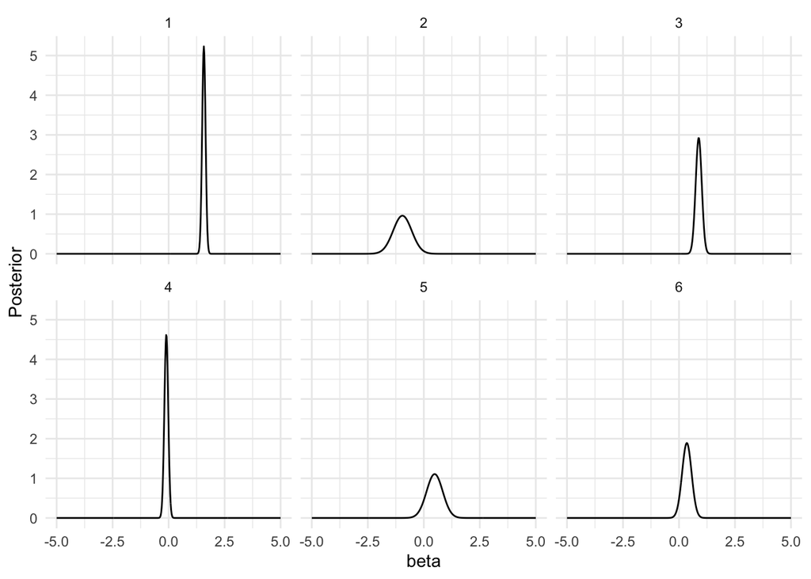

```r
laplace_beta %>%
  ggplot(aes(x = theta, y = pdf)) +
  geom_line() +
  facet_wrap(~index) +
  theme_minimal() +
  labs(x = "beta", y = "Posterior")
```

### 2.7.2 Empirical Bayes with one C++ template

Now that we have the Laplace marginals for `beta`, we can think about what we would do if we wanted to get them for all of the elements of the latent field. One approach would be to create separate `TMB` templates for each named random effect (`beta`, `nu` and `epsilon`). To see what this would look like, have a look at `epil_beta_index.cpp`, `epil_nu_index.cpp` and `epil_epsilon_index.cpp`.

What might be better is to do it in one `TMB` template, `epil_index.cpp` (see appendix):

```r
compile("epil_index.cpp")
```

```
## [1] 0
```

```r
dyn.load(dynlib("epil_index"))
```

We’re going to use a data structure to pass to `epil_index`. A `toggle` value of `0` corresponds to `beta`, a toggle value of `1` corresponds to `nu`, and a toggle value of `2` corresponds to `epsilon`:

```r
index_controller <- data.frame(
  "toggle" = c(rep(0, dat$K), rep(1, dat$N * dat$J),  rep(2, dat$N)),
  "i" = c(1:dat$K, 1:(dat$N * dat$J), 1:dat$N)
)
```

Create function which takes as input the index `i` (from `index_controller`), the results of optimisation for $\theta$, and a grid of values for $x_i$ to evaluate at:

```r
xi_laplace_marginal <- function(i, opt_theta, finegrid) {
  dat$toggle <- index_controller[i, "toggle"]
  dat$i <- index_controller[i, "i"]

  theta_names <- unique(names(opt_theta$par))
  map_fixed_theta <- list()
  param_fixed_theta <- param

  for(theta in theta_names) {
    map_fixed_theta[[theta]] <- rep(factor(NA), length(param[[theta]]))
    param_fixed_theta[[theta]] <- opt_theta$par[names(opt_theta$par) == theta]
  }

  #' Prepare the initialisation parameters if it's beta that we're toggling
  #' We fix the beta parameter to zero, as we're using beta_i and beta_minus_i
  if(dat$toggle == 0) {
    param_fixed_theta[["beta_i"]] <- param_fixed_theta$beta[i]
    param_fixed_theta[["beta_minus_i"]] <- param_fixed_theta$beta[-i]
    map_fixed_theta[["beta"]] <- rep(factor(NA), length(param[["beta"]]))
  }

  #' Or if it's epsilon that we're toggling
  #' We fix the epsilon parameter to zero, as we're using epsilon_i and epsilon_minus_i
  if(dat$toggle == 1) {
    param_fixed_theta[["nu_i"]] <- param_fixed_theta$nu[i]
    param_fixed_theta[["nu_minus_i"]] <- param_fixed_theta$nu[-i]
    map_fixed_theta[["nu"]] <- rep(factor(NA), length(param[["nu"]]))
  }

  #' Or if it's epsilon that we're toggling
  #' We fix the epsilon parameter to zero, as we're using epsilon_i and epsilon_minus_i
  if(dat$toggle == 2) {
    param_fixed_theta[["epsilon_i"]] <- param_fixed_theta$epsilon[i]
    param_fixed_theta[["epsilon_minus_i"]] <- param_fixed_theta$epsilon[-i]
    map_fixed_theta[["epsilon"]] <- rep(factor(NA), length(param[["epsilon"]]))
  }

  get_random <- function(dat) {
    if(dat$toggle == 0) return(c("beta_minus_i", "nu", "epsilon"))
    if(dat$toggle == 1) return(c("beta", "nu_minus_i", "epsilon"))
    if(dat$toggle == 2) return(c("beta", "nu", "epsilon_minus_i"))
  }

  obj_fixed_theta <- MakeADFun(
   data = dat,
   parameters = param_fixed_theta,
   random = get_random(dat),
   DLL = "epil_index",
   silent = TRUE,
   map = map_fixed_theta
  )

  quad <- aghq::aghq(
    ff = obj_fixed_theta,
    k = 3,
    startingvalue = 0,
    control = aghq::default_control_tmb()
  )

  pdf_and_cdf <- aghq::compute_pdf_and_cdf(quad, finegrid = fine_grid)[[1]]

  return(list("pdf_and_cdf" = pdf_and_cdf, "quad" = quad))
}
```

Now we can compute the Laplace marginal for all 301 random effects of $(\beta, \nu, \epsilon)$.

```r
fine_grid <- seq(-5, 5, length.out = 500)

#' It's possible to get errors with the initial value not being finite
safe_xi_laplace_marginal <- function(...) {
  return(tryCatch(xi_laplace_marginal(...), error = function(e) NULL))
}

laplace_x <- lapply(1:nrow(index_controller), safe_xi_laplace_marginal, opt_theta = opt_theta, finegrid = fine_grid)

laplace_beta_summary <- lapply(head(laplace_x, n = dat$K), function(result) summary(result$quad)$summarytable) %>%
  bind_rows()

rownames(laplace_beta_summary) <- paste0("beta[", 1:dat$K, "]")
```

# 3 Comparison

## 3.1 Table

Let’s look at the mean and standard deviation of each of the $\beta$ parameters:

```r
stan1 <- as.vector(t(summary(fit1)$summary[1:6, c(1, 3)]))
inla2 <- as.vector(t(fit2$summary.fixed[1:6, 1:2]))
inla3 <- as.vector(t(fit3$summary.fixed[1:6, 1:2]))
inla4 <- as.vector(t(fit4$summary.fixed[1:6, 1:2]))
inla5 <- as.vector(t(fit5$summary.fixed[1:6, 1:2]))
inla6 <- as.vector(t(fit6$summary.fixed[1:6, 1:2]))
inla7 <- as.vector(t(fit7$summary.fixed[1:6, 1:2]))
tmb8 <- as.vector(t(data.frame(sd_out$par.random[1:6], sqrt(sd_out$diag.cov.random[1:6]))))
glmmtmb9 <- as.vector(t(summary(fit9)$coefficients$cond[, c("Estimate", "Std. Error")]))
tmbstan10 <- as.vector(t(summary(fit10)$summary[1:6, c(1, 3)]))

fit11_beta_samples <- fit11_samples[, 1:6]
aghq11 <- as.vector(t(data.frame(mean = apply(fit11_beta_samples, 2, mean), sd = apply(fit11_beta_samples, 2, sd))))

adam12 <- as.vector(t(laplace_beta_summary[1:6, 1:2]))

df <- cbind(stan1, inla2, inla3, inla4, inla5, inla6, inla7, tmb8, glmmtmb9, tmbstan10, aghq11, adam12) %>%
  as.data.frame() %>%
  mutate(type = gl(2, 1, 12, labels = c("Mean", "SD")))

beta_i <- function(i) { c(paste0("beta_", i), paste0("sd(beta_", i, ")")) }
rownames(df) <- c(sapply(0:5, beta_i))
method_names <- c("Stan", "EB-G", "EB-SL", "EB-L", "Grid-G", "Grid-SL", "Grid-L", "TMB", "glmmTMB", "tmbstan", "aghq", "adam")
colnames(df) <- c(method_names, "type")

df %>%
  select(-type) %>%
  kableExtra::kable(digits = 3)
```

|  | Stan | EB-G | EB-SL | EB-L | Grid-G | Grid-SL | Grid-L | TMB | glmmTMB | tmbstan | aghq | adam |
| --- | --- | --- | --- | --- | --- | --- | --- | --- | --- | --- | --- | --- |
| beta_0 | 1.572 | 1.627 | 1.574 | 1.574 | 1.626 | 1.573 | 1.573 | 1.627 | 1.579 | 1.572 | 1.626 | 1.573 |
| sd(beta_0) | 0.078 | 0.075 | 0.075 | 0.075 | 0.078 | 0.078 | 0.078 | 0.076 | 0.073 | 0.078 | 0.075 | 0.076 |
| beta_1 | -0.955 | -0.926 | -0.953 | -0.954 | -0.927 | -0.954 | -0.956 | -0.926 | -0.949 | -0.953 | -0.937 | -0.955 |
| sd(beta_1) | 0.414 | 0.409 | 0.409 | 0.408 | 0.419 | 0.419 | 0.419 | 0.414 | 0.396 | 0.426 | 0.427 | 0.415 |
| beta_2 | 0.881 | 0.858 | 0.880 | 0.880 | 0.859 | 0.880 | 0.881 | 0.858 | 0.880 | 0.883 | 0.856 | 0.880 |
| sd(beta_2) | 0.139 | 0.134 | 0.134 | 0.134 | 0.138 | 0.138 | 0.138 | 0.136 | 0.129 | 0.139 | 0.141 | 0.136 |
| beta_3 | -0.100 | -0.100 | -0.103 | -0.103 | -0.101 | -0.103 | -0.104 | -0.101 | -0.103 | -0.104 | -0.096 | -0.103 |
| sd(beta_3) | 0.088 | 0.086 | 0.086 | 0.086 | 0.086 | 0.086 | 0.086 | 0.086 | 0.086 | 0.087 | 0.085 | 0.086 |
| beta_4 | 0.483 | 0.472 | 0.486 | 0.486 | 0.471 | 0.484 | 0.484 | 0.470 | 0.490 | 0.492 | 0.469 | 0.484 |
| sd(beta_4) | 0.376 | 0.355 | 0.355 | 0.355 | 0.365 | 0.365 | 0.365 | 0.360 | 0.342 | 0.357 | 0.371 | 0.360 |
| beta_5 | 0.349 | 0.340 | 0.350 | 0.350 | 0.340 | 0.350 | 0.351 | 0.340 | 0.349 | 0.348 | 0.345 | 0.350 |
| sd(beta_5) | 0.211 | 0.208 | 0.208 | 0.208 | 0.214 | 0.214 | 0.213 | 0.210 | 0.200 | 0.214 | 0.219 | 0.211 |

```r
saveRDS(df, "comparison-results.rds")
```

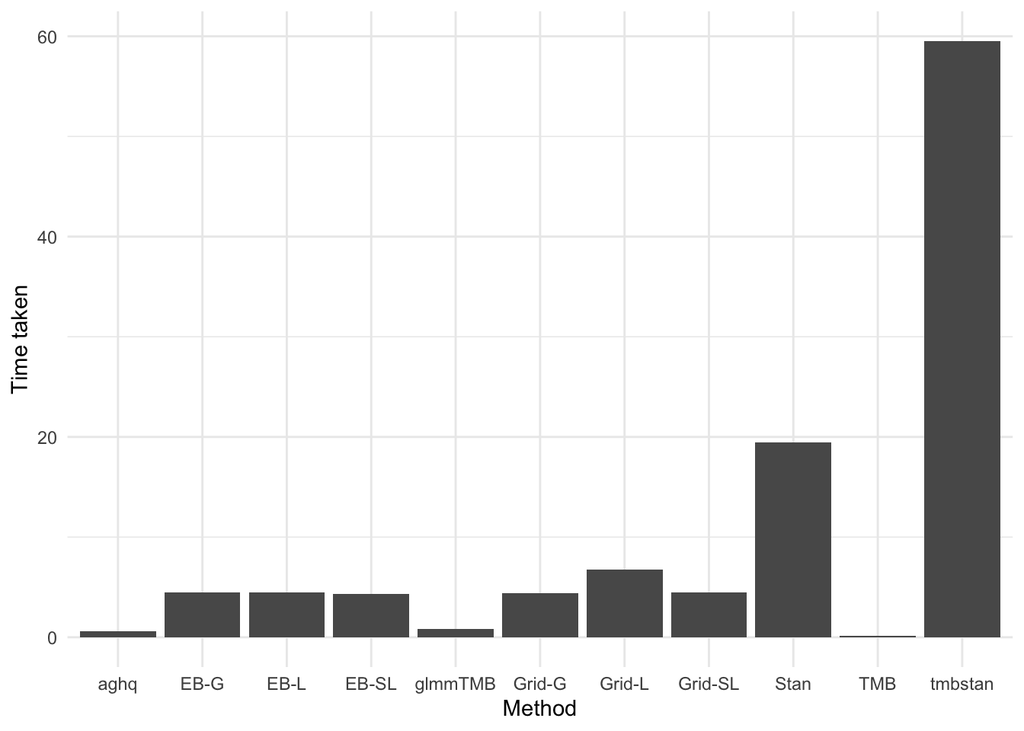

```r
time_df <- data.frame(
  time = c(time_fit1, time_fit2, time_fit3, time_fit4, time_fit5, time_fit6, time_fit7, time_fit8, time_fit9, time_fit10, time_fit11),
  method = head(method_names, n = 11)
)

time_df %>% ggplot(aes(x = method, y = time)) +
  geom_col() +
  theme_minimal() +
  labs(x = "Method", y = "Time taken")
```

## 3.2 Focus on $\beta_0$

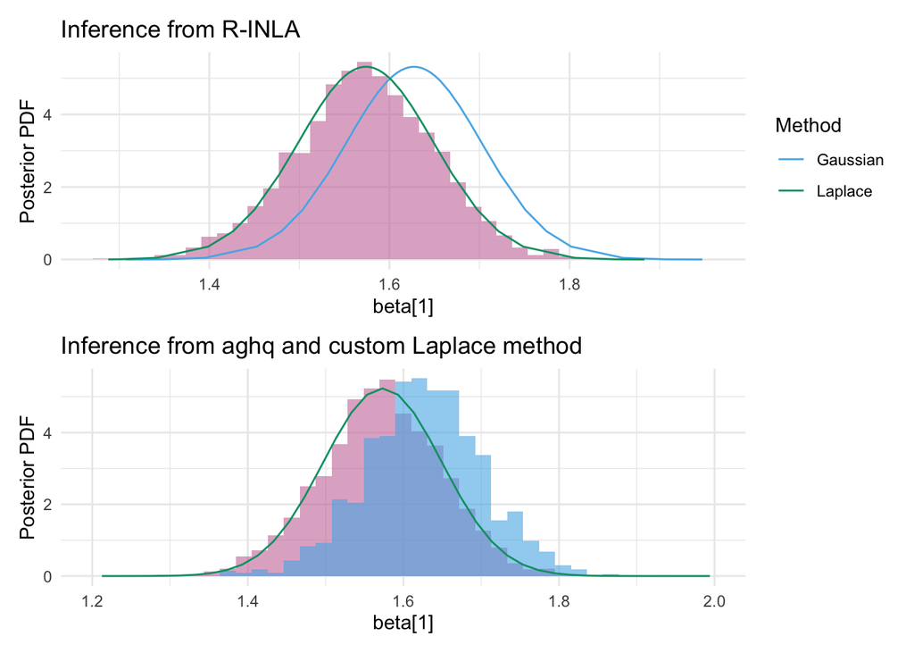

```r
#' Stan histogram base-plot
plot_pdf_stan <- ggplot(data.frame(x = rstan::extract(fit1, pars = "beta[1]")[[1]]), aes(x = x)) +
    geom_histogram(aes(y = ..density..), alpha = 0.6, fill = cbpalette[7], bins = 40) +
    theme_minimal() +
    labs(x = "beta[1]", y = "Posterior PDF")

beta0_inla_marginals <- bind_rows(
  data.frame(fit2$marginals.fixed$`(Intercept)`) %>%
    mutate(method = "Gaussian"),
  data.frame(fit4$marginals.fixed$`(Intercept)`) %>%
    mutate(method = "Laplace")
)

#' Add R-INLA results
plot_pdf_stan_inla <- plot_pdf_stan +
  geom_line(data = beta0_inla_marginals, aes(x = x, y = y, col = method)) +
  scale_color_manual(values = cbpalette) +
  labs(col = "Method", title = "Inference from R-INLA")

plot_pdf_stan_aghq <- plot_pdf_stan +
  geom_histogram(data = data.frame(x = fit11_beta_samples$`beta[1]`), aes(y = ..density..), alpha = 0.6, fill = cbpalette[1], bins = 40)

plot_pdf_stan_aghq <- plot_pdf_stan_aghq +
    geom_line(data = laplace_x[[1]]$pdf_and_cdf, aes(x = theta, y = pdf), col = cbpalette[2]) +
    lims(x = c(1.2, 2)) +
    labs(title = "Inference from aghq and custom Laplace method") +
    theme_minimal()

plot_intercept_comparison <- plot_pdf_stan_inla / plot_pdf_stan_aghq

plot_intercept_comparison
```

```r
ggsave("intercept-comparison.pdf", plot = plot_intercept_comparison, h = 6, w = 6.25)
```

## 3.3 Scatter plot against `tmbstan`

Assuming `tmbstan` to be the ground truth, we can do two dimensional plots to check the fit

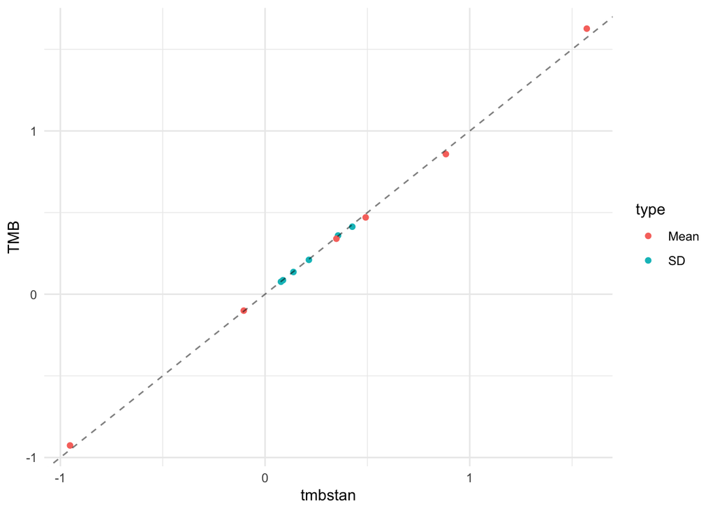

```r
ggplot(df) +
  geom_point(aes(x = tmbstan, y = TMB, col = type)) +
  geom_abline(intercept = 0, slope = 1, linetype = "dashed", alpha = 0.5) +
  theme_minimal()
```

## 3.4 Symmetric KL divergence

```r
head(fit2$summary.random$rand)$kld
```

```
## [1] 0 0 0 0 0 0
```

For `laplace` and `"simplified.laplace"` we can look for the random effect with the highest SKLD:

```r
skld <- function(fit) {
  #' Nu random effect
  id_rand <- which.max(fit$summary.random$rand$kld)
  print(fit$summary.random$rand[id_rand, ])
  #' Epsilon random effect
  id_Ind <- which.max(fit$summary.random$Ind$kld)
  print(fit$summary.random$Ind[id_Ind, ])
  return(list(id_rand = id_rand, id_Ind = id_Ind))
}

skld3 <- skld(fit3)
```

```
##      ID     mean        sd 0.025quant  0.5quant 0.975quant mode         kld
## 222 222 0.645863 0.2480358  0.1561084 0.6472347   1.129674   NA 0.001331823
##    ID      mean        sd 0.025quant  0.5quant 0.975quant mode         kld
## 56 56 0.9044046 0.2309653  0.4488055 0.9055538   1.355366   NA 0.006909513
```

```r
skld4 <- skld(fit4)
```

```
##      ID      mean        sd 0.025quant  0.5quant 0.975quant mode          kld
## 222 222 0.6429203 0.2476023  0.1546926 0.6439011   1.125762   NA 0.0007942658
##    ID      mean        sd 0.025quant 0.5quant 0.975quant mode         kld
## 56 56 0.9019214 0.2300221  0.4486929   0.9027   1.350875   NA 0.005744471
```

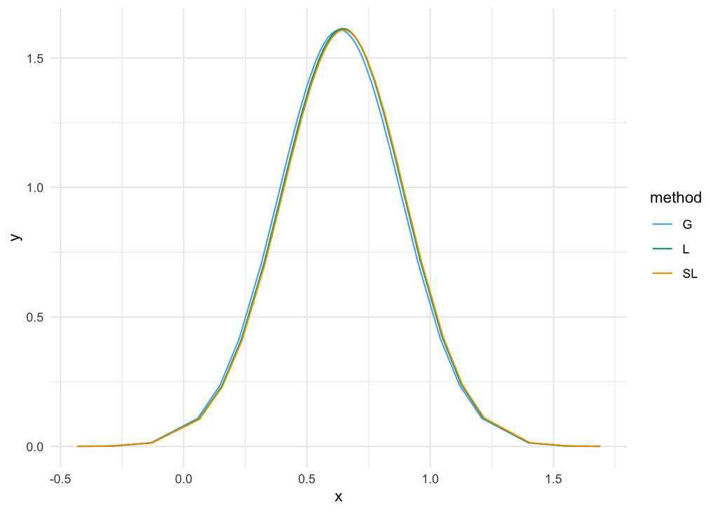

```r
plot_marginals <- function(random_effect, index) {
  marginal2 <- fit2$marginals.random[[random_effect]][paste0("index.", index)][[1]] %>%
    as.data.frame() %>%
    mutate(method = "G")

  marginal3 <- fit3$marginals.random[[random_effect]][paste0("index.", index)][[1]] %>%
    as.data.frame() %>%
    mutate(method = "SL")

  marginal4 <- fit4$marginals.random[[random_effect]][paste0("index.", index)][[1]] %>%
    as.data.frame() %>%
    mutate(method = "L")

  marginals <- bind_rows(marginal2, marginal3, marginal4)

  ggplot(marginals, aes(x = x, y = y, group = method, col = method)) +
    geom_line() +
    scale_color_manual(values = cbpalette) +
    theme_minimal()
}

plot_marginals("rand", index = skld3$id_rand)
```

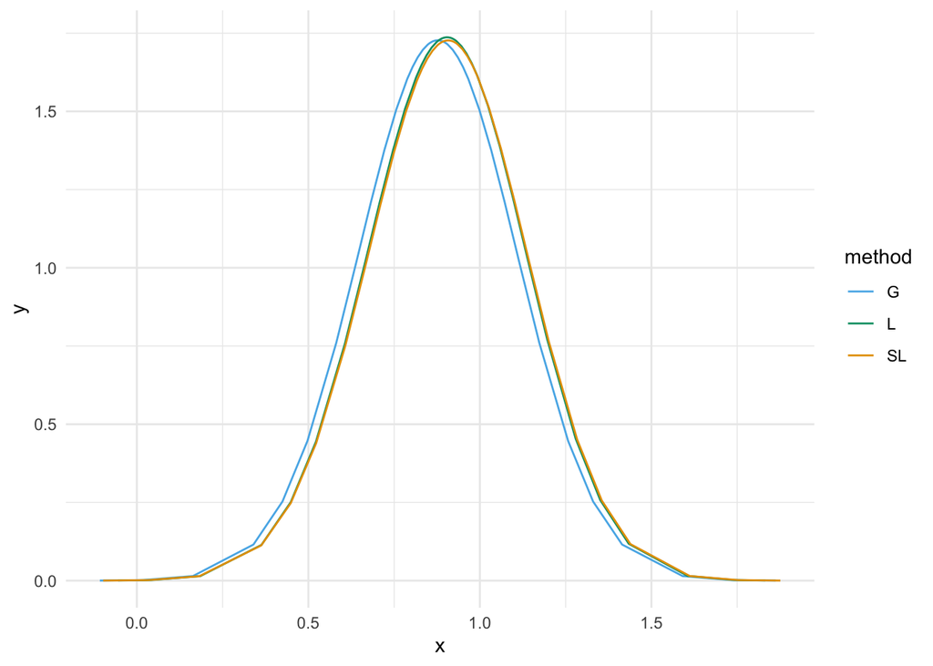

```r
plot_marginals("Ind", index = skld3$id_Ind)
```